# NYPD Shooting Incident Data Report

Trey Hendrix

Date Created: 260307 Date Modified: 260416

# Introduction

In this report, I analyze [the historical NYPD shooting incident dataset from data.gov](https://catalog.data.gov/dataset/archived_nypd-shooting-incident-data-historic). I focus on the demographics of shooters and victims and explore the implications of missing perpetrator information. The dataset is a massive collection of every shooting that occurred in NYC over approximately the last 20 years. It contains basic information about each shooting incident, including the time, location, and demographic details of the victim and perpetrator.

Note: the structure of the dataset changed between my submission of this assignment for module 3 (knit document/HTML only) and module 5 (reproducible Rmd), so the code has been updated to reflect that, although the data are presumably unchanged. This mostly affects the metadata, which are retrieved in a `tryCatch` in case further changes occur.

```r
library(tidyverse)
library(kableExtra) # for more aesthetic and customizable data tables
library(jsonlite) # for parsing JSON metadata
library(naniar) # for visualizing and analyzing missing data
library(scales) # for graph labels
```

# Importing Data and Metadata

Using the [“ARCHIVED_NYPD Shooting Incident Data (Historic)” on the data.gov website](https://catalog.data.gov/dataset/archived_nypd-shooting-incident-data-historic), we can copy the link for downloading the .csv format of the dataset. Similarly, we can also grab the metadata via this page (which is a JSON).

```r
raw_df <- read_csv("https://data.cityofnewyork.us/api/views/833y-fsy8/rows.csv?accessType=DOWNLOAD")
glimpse(raw_df)
```

```
## Rows: 29,744
## Columns: 21
## $ INCIDENT_KEY            <dbl> 231974218, 177934247, 255028563, 25384540, 726…
## $ OCCUR_DATE              <chr> "08/09/2021", "04/07/2018", "12/02/2022", "11/…
## $ OCCUR_TIME              <time> 01:06:00, 19:48:00, 22:57:00, 01:50:00, 01:58…
## $ BORO                    <chr> "BRONX", "BROOKLYN", "BRONX", "BROOKLYN", "BRO…
## $ LOC_OF_OCCUR_DESC       <chr> NA, NA, "OUTSIDE", NA, NA, NA, NA, NA, NA, NA,…
## $ PRECINCT                <dbl> 40, 79, 47, 66, 46, 42, 71, 69, 75, 69, 40, 42…
## $ JURISDICTION_CODE       <dbl> 0, 0, 0, 0, 0, 2, 0, 2, 0, 0, 0, 2, 0, 0, 2, 0…
## $ LOC_CLASSFCTN_DESC      <chr> NA, NA, "STREET", NA, NA, NA, NA, NA, NA, NA, …
## $ LOCATION_DESC           <chr> NA, NA, "GROCERY/BODEGA", "PVT HOUSE", "MULTI …
## $ STATISTICAL_MURDER_FLAG <lgl> FALSE, TRUE, FALSE, TRUE, TRUE, FALSE, TRUE, F…
## $ PERP_AGE_GROUP          <chr> NA, "25-44", "(null)", "UNKNOWN", "25-44", "18…
## $ PERP_SEX                <chr> NA, "M", "(null)", "U", "M", "M", NA, NA, "M",…
## $ PERP_RACE               <chr> NA, "WHITE HISPANIC", "(null)", "UNKNOWN", "BL…
## $ VIC_AGE_GROUP           <chr> "18-24", "25-44", "25-44", "18-24", "<18", "18…
## $ VIC_SEX                 <chr> "M", "M", "M", "M", "F", "M", "M", "M", "M", "…
## $ VIC_RACE                <chr> "BLACK", "BLACK", "BLACK", "BLACK", "BLACK", "…
## $ X_COORD_CD              <dbl> 1006343.0, 1000082.9, 1020691.0, 985107.3, 100…
## $ Y_COORD_CD              <dbl> 234270.0, 189064.7, 257125.0, 173349.8, 247502…
## $ Latitude                <dbl> 40.80967, 40.68561, 40.87235, 40.64249, 40.845…
## $ Longitude               <dbl> -73.92019, -73.94291, -73.86823, -73.99691, -7…
## $ Lon_Lat                 <chr> "POINT (-73.92019278899994 40.80967347200004)"…
```

Most of these columns are self-explanatory; however, we will need to dig into the metadata to make sure we understand a few of them.

```r
# The structure of metadata can change somewhat frequently, so this code chunk is allowed to fail without crashing the .Rmd
tryCatch({
  meta_list <- fromJSON("https://catalog.data.gov/harvest_record/70db1520-dadb-4dbd-b983-2ea04341fea0/raw")
  column_meta_list <- meta_list$distribution |>
    filter(mediaType == "application/json") |>
    pull(downloadURL) |>
    fromJSON()

  column_def_df <- column_meta_list$meta$view$columns

  column_def_df |>
    filter(fieldName %in% str_to_lower(c("X_COORD_CD", "Y_COORD_CD"))) |>
    select(fieldName, description) |>
    kbl() |>
    kable_classic_2()

}, error = function(e) {
  print("Metadata retrival has failed. This is probably because the structure has been changed since this report was created.")
  print(str_glue("Error: {e}"))
  print("The report will proceed anyway without the metadata.")
}

)
```

| fieldName | description |
| --- | --- |
| x_coord_cd | Midblock X-coordinate for New York State Plane Coordinate System, Long Island Zone, NAD 83, units feet (FIPS 3104) |
| y_coord_cd | Midblock Y-coordinate for New York State Plane Coordinate System, Long Island Zone, NAD 83, units feet (FIPS 3104) |

For our geographic data, we will stick to the standard latitude and longitude fields, so I will drop these variables in the section below.

# Data Cleaning

First, I will also perform some quick cleaning, such as consistently coding missing values and renaming columns.

```r
null_str_values <- c("(null)", "UNKNOWN") # We will replace these with NAs in R to better identify and deal with missing data

df <- raw_df |>
  rename_with(.fn = str_to_lower) |>  # make the column names lowercase for consistency
  mutate(
    occur_date = mdy(occur_date), # mdy = month day year date format
    across( # clean up NA values stored as strings
      where(is.character),
      .fn = function(x) {ifelse(x %in% null_str_values, NA_character_, x)}
    ),
    precinct = as.character(precinct) # These are not meaningful as integers (they are categories)
  ) |>
  select(-c(x_coord_cd, y_coord_cd)) # drop unwanted columns
```

From the previous `glimpse` call above, it is clear that many records have missing values. The `naniar` R package is my favorite way to understand patterns in missing data. First, let’s see which variables have missing records:

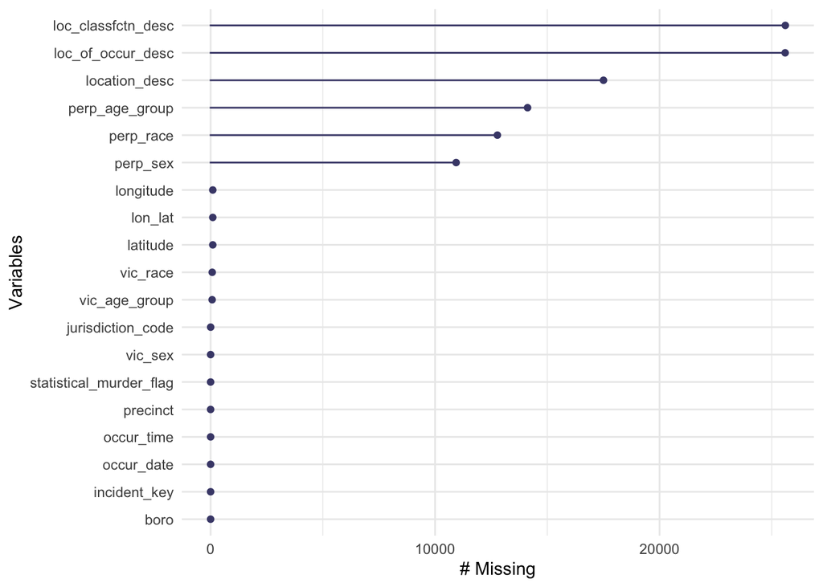

```r
gg_miss_var(df)
```

```r
df |>
  miss_var_summary() |>
  mutate(pct_miss = str_glue("{as.numeric(round(pct_miss, 1))}%")) |> # drop the odd S3 data type
  kable() |>
  kable_classic_2(full_width = FALSE)
```

| variable | n_miss | pct_miss |
| --- | --- | --- |
| loc_classfctn_desc | 25603 | 86.1% |
| loc_of_occur_desc | 25596 | 86.1% |
| location_desc | 17503 | 58.8% |
| perp_age_group | 14120 | 47.5% |
| perp_race | 12776 | 43% |
| perp_sex | 10938 | 36.8% |
| latitude | 97 | 0.3% |
| longitude | 97 | 0.3% |
| lon_lat | 97 | 0.3% |
| vic_race | 72 | 0.2% |
| vic_age_group | 68 | 0.2% |
| jurisdiction_code | 2 | 0% |
| incident_key | 0 | 0% |
| occur_date | 0 | 0% |
| occur_time | 0 | 0% |
| boro | 0 | 0% |
| precinct | 0 | 0% |
| statistical_murder_flag | 0 | 0% |
| vic_sex | 0 | 0% |

Fortunately, the majority of records only have a small portion of missing records for most variables (`longitude` to `boro` in the graph above). These variables are also fairly essential/fundamental to understanding a crime that I feel comfortable dropping any records that are missing this information. However, a handful of variables are frequently missing. The location information `loc_classfctn_desc` and `loc_of_occur_desc` are missing too frequently to be informative, so I will largely ignore them. `location_desc` is available for 40% of records while information about the perpetrator (`perp_age_group`, `perp_race`, and `perp_sex`) are available for the majority of incidents. I am interested in digging into this pattern of missing data and will do so in the second analysis section, so I will not drop or impute these data.

**Bias Observation #1**: Approximately half of our records are missing information about the race and sex of the perpetrator, while the victims’ race and sex are rarely missing. We need to keep this bias in the data in mind when analyzing perpetrator-victim dynamics. This bias is somewhat intuitive: crimes are reported by victims, not perpetrators.

```r
# Dropping records with critical missing information
df <- df |>
  drop_na(jurisdiction_code, vic_age_group, vic_race, lon_lat, longitude, latitude)

# Creating a column to track when information is missing about a perp
df <- df |>
  mutate(missing_perp_info = is.na(perp_sex) | is.na(perp_age_group) | is.na(perp_race))
```

# Analysis 1 - Racial Disparities

At a first glance, one of the most striking features of this dataset that I came across relates to racial disparities. Before we get started, I’ll check that all of the racial groups are reasonably well represented in the data with a couple quick frequency tables:

```r
quick_freq_table <- function(var, focal_df = df) {
  focal_df |>
    count(.data[[var]]) |>
    mutate(
      percent = n/sum(n),
      percent = paste0(round(percent * 100, 1), "%")
    ) |>
    arrange(n) |>
    kbl() |>
    kable_classic_2(full_width = FALSE)
}

quick_freq_table("vic_race", df)
```

| vic_race | n | percent |
| --- | --- | --- |
| AMERICAN INDIAN/ALASKAN NATIVE | 13 | 0% |
| ASIAN / PACIFIC ISLANDER | 476 | 1.6% |
| WHITE | 725 | 2.5% |
| BLACK HISPANIC | 2913 | 9.9% |
| WHITE HISPANIC | 4478 | 15.2% |
| BLACK | 20921 | 70.9% |

```r
quick_freq_table("perp_race", df)
```

| perp_race | n | percent |
| --- | --- | --- |
| AMERICAN INDIAN/ALASKAN NATIVE | 2 | 0% |
| ASIAN / PACIFIC ISLANDER | 184 | 0.6% |
| WHITE | 303 | 1% |
| BLACK HISPANIC | 1472 | 5% |
| WHITE HISPANIC | 2636 | 8.9% |
| BLACK | 12228 | 41.4% |
| NA | 12701 | 43% |

Again, we see that the most common race of the perpetrator is unknown. We will revisit this observation in the next section and, for now, focus on observations with complete perpetrator information. Additionally, there are too few “AMERICAN INDIAN/ALASKAN NATIVE” records to do meaningful analysis and comparisons, so I will drop those records.

```r
racial_df <- df |>
  filter(vic_race != "AMERICAN INDIAN/ALASKAN NATIVE") |>
  filter(is.na(perp_race) | perp_race != "AMERICAN INDIAN/ALASKAN NATIVE")

racial_known_df <- racial_df |>
  filter(!is.na(perp_race))
```

Let’s take another look at the perpetrator frequency table with the missing perp information filtered out:

```r
quick_freq_table("perp_race", racial_known_df)
```

| perp_race | n | percent |
| --- | --- | --- |
| ASIAN / PACIFIC ISLANDER | 184 | 1.1% |
| WHITE | 303 | 1.8% |
| BLACK HISPANIC | 1472 | 8.8% |
| WHITE HISPANIC | 2635 | 15.7% |
| BLACK | 12223 | 72.7% |

```r
# Calculate the date range for the dataset of the statement below
min_year <- df$occur_date |>
  year() |>
  min()

max_year <- df$occur_date |>
  year() |>
  max()
```

A quick consultation with the [Wikipedia page Race and Ethnicity in New York City](https://en.wikipedia.org/wiki/Race_and_ethnicity_in_New_York_City) suggests that the demographics of shooting victims and perpetrators are inconsistent with NYC as a whole. Most dramatically, during the time period of our dataset (2006 to 2024), we can approximate from the census data reported on the Wikipedia page that 1 in 4 NYC residents is black. However, our frequency tables above show that 7 out of 10 shooting victims are black, and 7 out of 10 known shooting perpetrators are black.

**Bias Observation #2** As stated above, we have uncovered a prominent racial bias in these shooting incident data. Assuming these data are representative, this amounts to both a statistical bias and a institutional racial bias. However, I want to be careful and acknowledge my personal biases in this case, the complexity of the data, and reframe my research question in light of this.

1. With these kind of data, it is important to reiterate the adage “correlation is not causation.” To understand the drivers of violent crime, we can’t look at a single variable in isolation, even when we spot an eye catching pattern. Race and crime in the US is a complex and controversial topic. I do not feel that I have the expertise to expound on the topic. However, [this Wikipedia article on US race and crime](https://en.wikipedia.org/wiki/Race_and_crime_in_the_United_States) is a good introduction to the topic for those interested. In short, for this dataset, if we want to understand the drivers of shooting incidents, we only have a handful of variables (e.g., victim and perp race), but academic research has indicated that a plethora of factors may drive this violence: socioeconomic class, education, housing segregation, and even lead pollution. Most of these are not present in our dataset.
2. Although I want to be measured in my approach to this analysis, I recognize that I personally believe that systemic racism is an important factor in violent crime and policing in the US. This is likely why I chose to look at `vic_race` and `perp_race` as the first analysis of my project.
3. In light of #1 and #2 above, I think it is appropriate to narrow my analysis and ask a more specific question that the data are appropriate for: **given the overrepresentation of certain demographic groups in our data, is there an association between the races of known perpetrators and victims? In other words, are shooting incidents more inter- (between races) or intraracial (within a race) than we might expect?**

Given this new focus, let’s visualize the joint distribution of our victim and perpetrator demographic data with a heatmap:

```r
# I will reuse this theme throughout this report for graphs
cbw_theme <- theme_bw() +  # cbw = centered black and white theme
  theme(plot.title = element_text(hjust = 0.5))

cbw_rotated_theme <- function(angle = -45, hjust = 0, vjust = 1) { # rotate x-axis text
  cbw_theme +
    theme(axis.text.x = element_text(angle = angle, hjust = hjust, vjust = vjust))
}
```

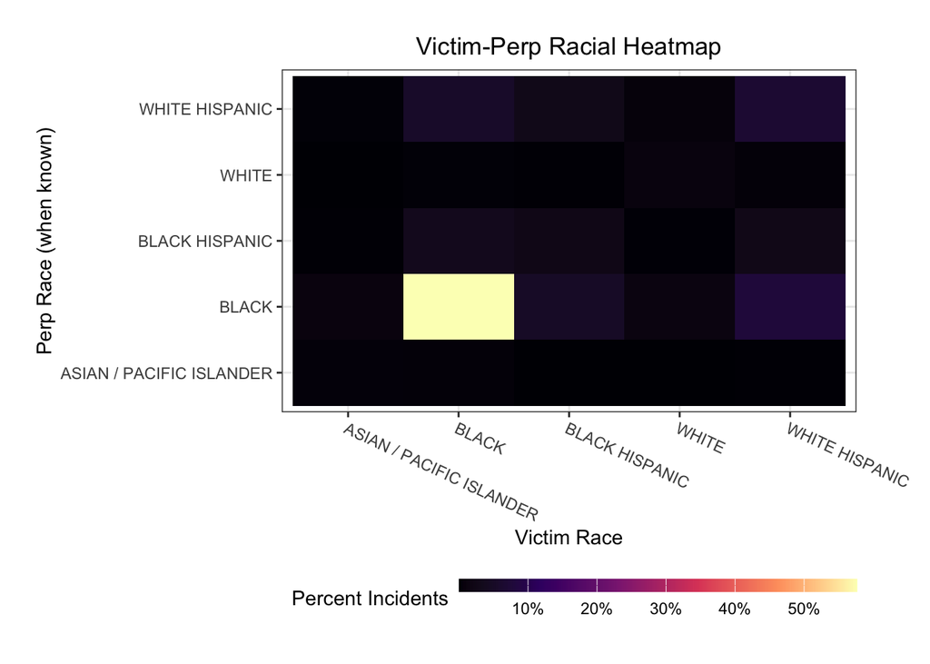

```r
racial_known_df |>
  filter(!is.na(perp_race)) |>
  group_by(vic_race, perp_race) |>
  summarize(cases = n(), .groups = "drop") |>
  mutate(percent_cases = cases/sum(cases)) |>
  ggplot(aes(x = vic_race, y = perp_race, fill = percent_cases)) +
  geom_tile() +
  cbw_rotated_theme(angle = -25) +
  labs(
    x = "Victim Race",
    y = "Perp Race (when known)",
    title = "Victim-Perp Racial Heatmap",
    fill = "Percent Incidents"
  ) +
  scale_fill_viridis_c(
    label = label_percent(),
    option = "magma",
    guide = guide_colorbar( # Make the color bar less squished
      barwidth = unit(15, "lines"),
      barheight = unit("0.5", "lines")
    )
  ) +
  theme(
    legend.position = "bottom",
    legend.justification = "left",
    plot.margin = margin( # Add to right margin to account for rotated x-axis text
      t = 20, b = 20, l = 20, r = 40,
      unit = "pt"
    )
  )
```

Here, the black-black combination stands out as accounting for more than half of incidents, suggesting a lack of statistical independence between victim and perpetrator race. However, we need to remember that this group is overrepresented in the data in general, so we should formally test this with a chi-squared model.

```r
chi_model <- chisq.test(racial_known_df$vic_race, racial_known_df$perp_race)
print(chi_model)
```

```
##
##  Pearson's Chi-squared test
##
## data:  racial_known_df$vic_race and racial_known_df$perp_race
## X-squared = 7052.7, df = 16, p-value < 2.2e-16
```

This p-value is highly significant, indicating a statistical association between victim and perpetrator race. We can visualize the model’s Pearson residuals to understand which groups influenced this result the most. These residuals follow the formula: (observed - expected) / sqrt(expected). The residuals are, thus, standardized, with positive values indicating that more incidents of a particular racial combination occurred than expected while negative values suggest fewer incidents than expected occurred.

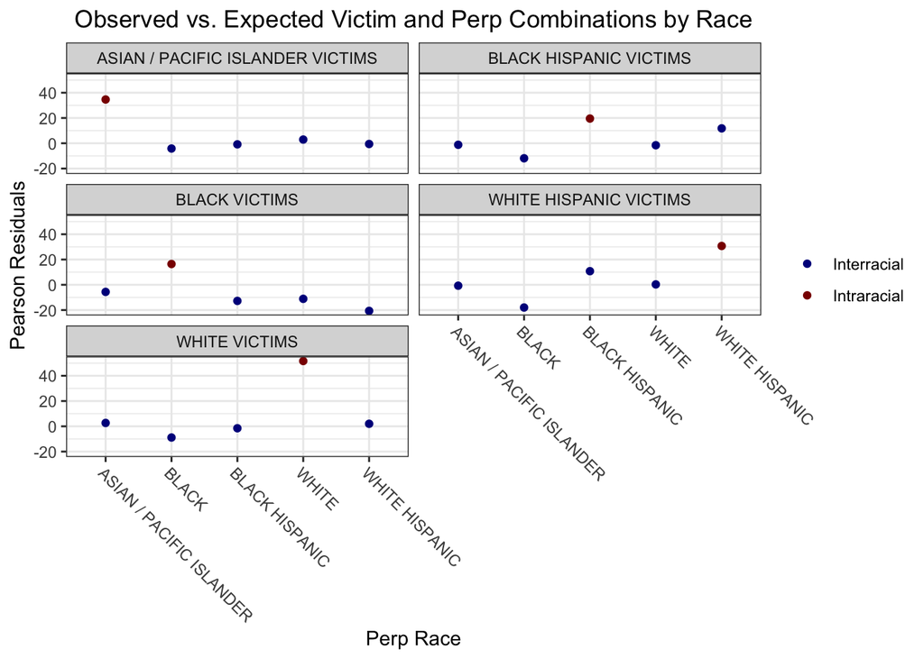

```r
chi_resid_df <- chi_model$residuals |>
  as.data.frame() |>
  rename(
    vic_race = "racial_known_df.vic_race",
    perp_race = "racial_known_df.perp_race",
    st_resid = "Freq"
  )

chi_resid_df |>
  mutate(type = ifelse(vic_race == perp_race, "Intraracial", "Interracial")) |>
  mutate(vic_race = paste(vic_race, "VICTIMS")) |>
  ggplot(aes(x = perp_race, y = st_resid, color = type)) +
  geom_point() +
  facet_wrap(~vic_race, ncol = 2) +
  cbw_rotated_theme() +
  labs(
    title = "Observed vs. Expected Victim and Perp Combinations by Race",
    x = "Perp Race",
    y = "Pearson Residuals",
    color = ""
  ) +
  scale_color_manual(values = c("Interracial" = "darkblue", "Intraracial" = "darkred"))
```

One pattern that arises from these residuals is that a larger number than expected of intraracial (the victim and perpetrator belong to the same demographic group) incidents is most responsible for the statistical dependence between victim and perpetrator race. Furthermore, the largest residuals come from the unexpectedly high rates of intraracial shootings involving asian/Pacific islander and white groups. I was somewhat surprised by this result since the rate of intraracial shootings is not particularly pronounced within these two groups:

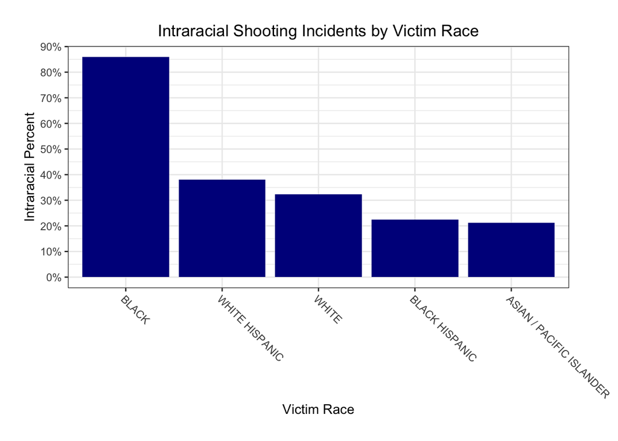

```r
racial_known_df |>
  group_by(vic_race) |>
  summarize(intraracial_percent = mean(vic_race == perp_race), .groups = "drop") |>
  mutate(vic_race = fct_reorder(vic_race, intraracial_percent, .desc = TRUE)) |>
  ggplot(aes(x = vic_race, y = intraracial_percent)) +
  geom_col(fill = "darkblue") +
  cbw_rotated_theme() +
  labs(
    x = "Victim Race",
    y = "Intraracial Percent",
    title = "Intraracial Shooting Incidents by Victim Race"
  ) +
  theme(plot.margin = margin(
    t = 20, b = 20, l = 20, r = 40,
    unit = "pt"
  )) +
  scale_y_continuous(
    labels = label_percent(),
    breaks = pretty_breaks(n = 10)
  )
```

However, we should be cautious about flagging these two groups, especially Asian/Pacific islander since they have much less representation in our dataset, which means our residuals might just be volatile rather than genuinely large. Additionally, it is important to reiterate that we have still not uncovered the “cause” of shootings in NYC. For example, due to the history of racial segregation in the US, the race of a perpetrator might be a proxy of some other variable. If most victims are shot near their homes, then the race of the perpetrator might be most explained by that simple fact. We can see evidence of this racial segregation in our dataset:

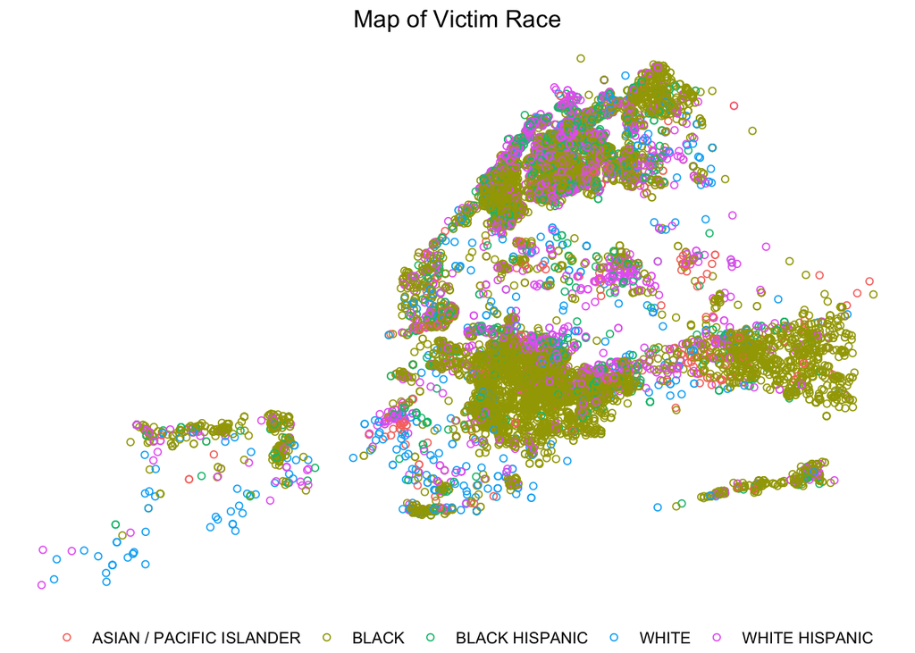

```r
racial_known_df |>
  ggplot(aes(x = longitude, y = latitude, color = vic_race)) +
  geom_point(shape = 1) +
  theme_void() +
  labs(title = "Map of Victim Race", color = "") +
  theme(
    legend.position = "bottom",
    plot.title = element_text(hjust = 0.5)
  )
```

Overall, we have found a statistical association between the race of victims and perpetrators driven by higher than expected rates of intraracial shootings. This analysis reminds me of the importance of having specific statistical hypotheses and interrogating initial results and visualizations.

# Analysis 2 - The Hidden World of Perps

The name of the `naniar` package is a reference to C.S. Lewis’ Narnia fantasy book series. The package’s author sees missing data like the mythical realm of Narnia, a hidden other dimension to our data ([source](https://cran.r-project.org/web/packages/naniar/readme/README.html)). In many statistical analyses, there is a tendency to immediately drop records with missing data and then proceed with further analyses. This can be a critical mistake depending on the type of missing data we are dealing with.

Broadly, there are three types of missing data: **missing completely at random (MCAR), missing at random (MAR), and missing not at random (MNAR)**. MCAR is the easiest to deal with since it means that our data are really just a random sample of a theoretical, more complete dataset. MAR is a bit trickier and refers to data that are missing due to the another observed variable in our dataset. For example, in weather data, we might be missing humidity measurements only at high temperatures (also recorded in our dataset) due to the equipment failing in high heat environments. We can correct for MAR with some statistical care. MNAR is the worst case scenario: the missing data are caused by something not captured in our dataset. This is not possible to fix without adding more data that explain the problematic pattern in the missing records.

Since such a high proportion of our records are missing perp data, we can ask: **Is information about perpetrators missing completely at random in our dataset?**

If the data are MCAR, then the rate should be roughly constant across groups. Given our previous focus on victim race and finding about the overrepresentation of intraracial shootings, we can look at the percent of missing perp information across its categories:

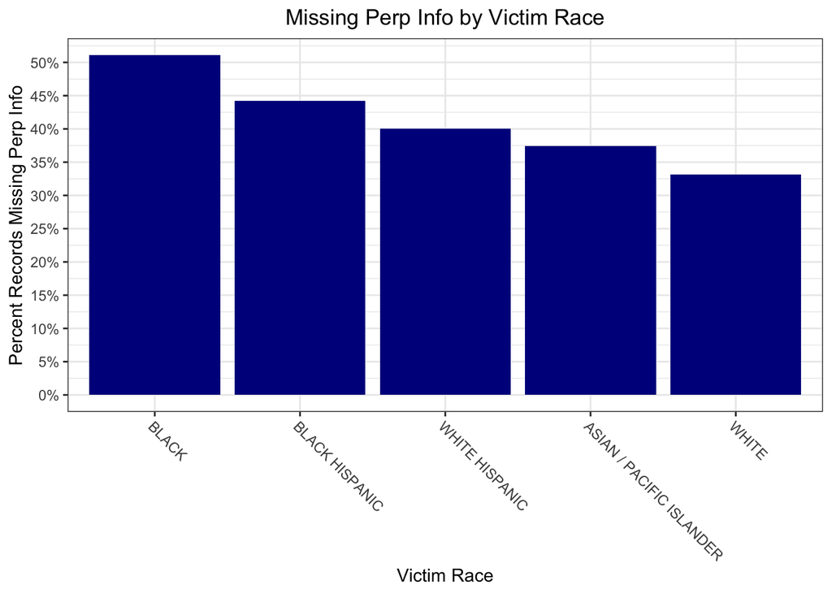

```r
racial_df |>
  group_by(vic_race) |>
  summarize(mean_missing_perp_info = mean(missing_perp_info), .groups = "drop") |>
  ungroup() |>
  mutate(vic_race = fct_reorder(vic_race, mean_missing_perp_info, .desc = TRUE)) |>
  ggplot(aes(x = vic_race, y = mean_missing_perp_info)) +
  geom_col(fill = "darkblue") +
  labs(
    x = "Victim Race",
    y = "Percent Records Missing Perp Info",
    title = "Missing Perp Info by Victim Race"
  ) +
  scale_y_continuous(labels = label_percent(), breaks = pretty_breaks(n = 10)) +
  cbw_rotated_theme()
```

These are substantial differences, but we can validate this with a logistic linear model. If victim race is a significant predictor of missing perp information, then our data are by definition MAR. For these models, I will set the reference level to the most common classes in the model since this can improve model stability.

```r
# Set reference levels for our categorical variables
mod_df <- racial_df |>
  mutate(
    vic_race = relevel(as.factor(vic_race), ref = "BLACK")
  )

race_glm <- glm(missing_perp_info ~ vic_race, data = mod_df, family = "binomial")
summary(race_glm)
```

```
##
## Call:
## glm(formula = missing_perp_info ~ vic_race, family = "binomial",
##     data = mod_df)
##
## Coefficients:
##                                  Estimate Std. Error z value Pr(>|z|)
## (Intercept)                       0.04313    0.01383   3.118  0.00182 **
## vic_raceASIAN / PACIFIC ISLANDER -0.55844    0.09573  -5.833 5.44e-09 ***
## vic_raceBLACK HISPANIC           -0.27693    0.03979  -6.960 3.41e-12 ***
## vic_raceWHITE                    -0.74664    0.08012  -9.319  < 2e-16 ***
## vic_raceWHITE HISPANIC           -0.44878    0.03349 -13.399  < 2e-16 ***
## ---
## Signif. codes:  0 '***' 0.001 '**' 0.01 '*' 0.05 '.' 0.1 ' ' 1
##
## (Dispersion parameter for binomial family taken to be 1)
##
##     Null deviance: 40866  on 29510  degrees of freedom
## Residual deviance: 40566  on 29506  degrees of freedom
## AIC: 40576
##
## Number of Fisher Scoring iterations: 4
```

All predictors are highly significant and have negative estimates, meaning that a victim being any other race than black reduces the probability that perp information will be missing.

However, let’s check if we can predict missing perp information via another variable that we have seen previously - borough:

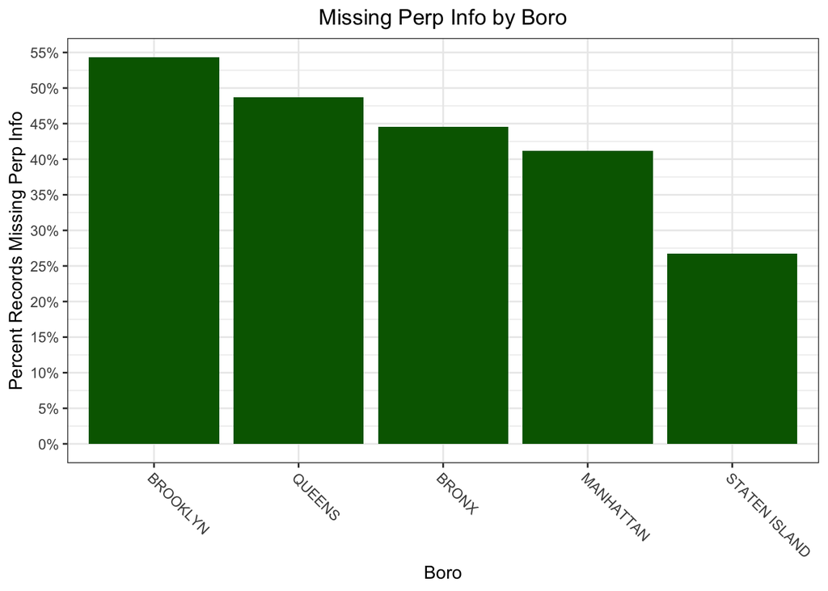

```r
df |>
  group_by(boro) |>
  summarize(mean_missing_perp_info = mean(missing_perp_info)) |>
  ungroup() |>
  mutate(boro = fct_reorder(boro, mean_missing_perp_info, .desc = TRUE)) |>
  ggplot(aes(x = boro, y = mean_missing_perp_info)) +
  geom_col(fill = "darkgreen") +
  labs(
    x = "Boro",
    y = "Percent Records Missing Perp Info",
    title = "Missing Perp Info by Boro"
  ) +
  scale_y_continuous(labels = label_percent(), breaks = pretty_breaks(n = 10)) +
  cbw_rotated_theme()
```

Again, these are fairly large differences among are groups, but we’ll double check them with a GLM.

```r
mod_df <- mod_df |>
  mutate(boro = relevel(as.factor(boro), ref = "BROOKLYN")) # most common Borough in dataset

boro_glm <- glm(missing_perp_info ~ boro, data = mod_df, family = "binomial")
summary(boro_glm)
```

```
##
## Call:
## glm(formula = missing_perp_info ~ boro, family = "binomial",
##     data = mod_df)
##
## Coefficients:
##                   Estimate Std. Error z value Pr(>|z|)
## (Intercept)        0.17212    0.01864   9.235  < 2e-16 ***
## boroBRONX         -0.39126    0.02844 -13.756  < 2e-16 ***
## boroMANHATTAN     -0.52941    0.03734 -14.177  < 2e-16 ***
## boroQUEENS        -0.22367    0.03550  -6.301 2.96e-10 ***
## boroSTATEN ISLAND -1.18078    0.08146 -14.495  < 2e-16 ***
## ---
## Signif. codes:  0 '***' 0.001 '**' 0.01 '*' 0.05 '.' 0.1 ' ' 1
##
## (Dispersion parameter for binomial family taken to be 1)
##
##     Null deviance: 40866  on 29510  degrees of freedom
## Residual deviance: 40411  on 29506  degrees of freedom
## AIC: 40421
##
## Number of Fisher Scoring iterations: 4
```

Since Brooklyn is our reference level, this model unsurprisingly finds that being in any other borough reduces the probability of missing perp data. All predictors are highly significant again. We already saw that race clusters geographically in our dataset, so do we need both `boro` and `vic_race` in our model? We can check by including both in a single model.

```r
boro_race_glm <- glm(missing_perp_info ~ boro + vic_race, data = mod_df, family = "binomial")
summary(boro_race_glm)
```

```
##
## Call:
## glm(formula = missing_perp_info ~ boro + vic_race, family = "binomial",
##     data = mod_df)
##
## Coefficients:
##                                  Estimate Std. Error z value Pr(>|z|)
## (Intercept)                       0.23364    0.01924  12.144  < 2e-16 ***
## boroBRONX                        -0.32260    0.02949 -10.940  < 2e-16 ***
## boroMANHATTAN                    -0.47701    0.03783 -12.609  < 2e-16 ***
## boroQUEENS                       -0.17389    0.03585  -4.851 1.23e-06 ***
## boroSTATEN ISLAND                -1.12176    0.08196 -13.687  < 2e-16 ***
## vic_raceASIAN / PACIFIC ISLANDER -0.56202    0.09646  -5.826 5.67e-09 ***
## vic_raceBLACK HISPANIC           -0.18610    0.04077  -4.565 4.99e-06 ***
## vic_raceWHITE                    -0.67250    0.08117  -8.285  < 2e-16 ***
## vic_raceWHITE HISPANIC           -0.36544    0.03438 -10.630  < 2e-16 ***
## ---
## Signif. codes:  0 '***' 0.001 '**' 0.01 '*' 0.05 '.' 0.1 ' ' 1
##
## (Dispersion parameter for binomial family taken to be 1)
##
##     Null deviance: 40866  on 29510  degrees of freedom
## Residual deviance: 40206  on 29502  degrees of freedom
## AIC: 40224
##
## Number of Fisher Scoring iterations: 4
```

Again, every predictor is significant. However, to supplement individual predictor p-values, we can use a likelihood ratio test to test if adding `vic_race` to our `boro_glm` model significantly improves model fit:

```r
anova(boro_glm, boro_race_glm)
```

```
## Analysis of Deviance Table
##
## Model 1: missing_perp_info ~ boro
## Model 2: missing_perp_info ~ boro + vic_race
##   Resid. Df Resid. Dev Df Deviance  Pr(>Chi)
## 1     29506      40411
## 2     29502      40206  4   204.87 < 2.2e-16 ***
## ---
## Signif. codes:  0 '***' 0.001 '**' 0.01 '*' 0.05 '.' 0.1 ' ' 1
```

Our full model with both `boro` and `vic_race` is a significant improvement.

**Bias Observation #3**: Given these model results, we can be reasonably confident that our missing perpetrator data are not missing completely at random (MCAR). This is a significant source of statistical bias that requires a different suite of tools and models.

In conclusion, we have observed that both borough and victim race are statistically correlated with our missing perpetrator data. This meets the definition of missing at random (MAR) and means that we cannot simply drop cases with missing perpetrator data and proceed normally. We need to adjust for this “hidden” world of missing perpetrators using methods such as [multiple imputation](https://www.publichealth.columbia.edu/research/population-health-methods/missing-data-and-multiple-imputation). This applies to our previous analysis, Analysis 1 - Racial Disparities. I previously reported a statistical association between victim and perpetrator race for known perpetrators. However, a more accurate way to express this is: a statistical association between victim and perpetrator race for known perpetrators in this dataset in which missing perpetrator information is in turn associated with borough and victim race. This is messier, less compelling, and a preliminary result calling for a more complex analysis. Nevertheless, responsible data science often means careful language and incremental, iterative analyses.

# Session Info

This HTML report was generated at 2026-04-16 08:42:49 EDT.